# Causes of deaths 2011-2021

Report generated on Date: 2025-05-09 Time: 09:15

# 1 Aim

We aim to 1. explore the mortality trends over time, by cause in Switzerland 2. assess excess mortality during 2020-2021, by cause 3. investigate the correlations between mortality causes (e.g., COVID-19 and other causes)

# 2 Data

## 2.1 Causes of deaths

### 2.1.1 2020-2021

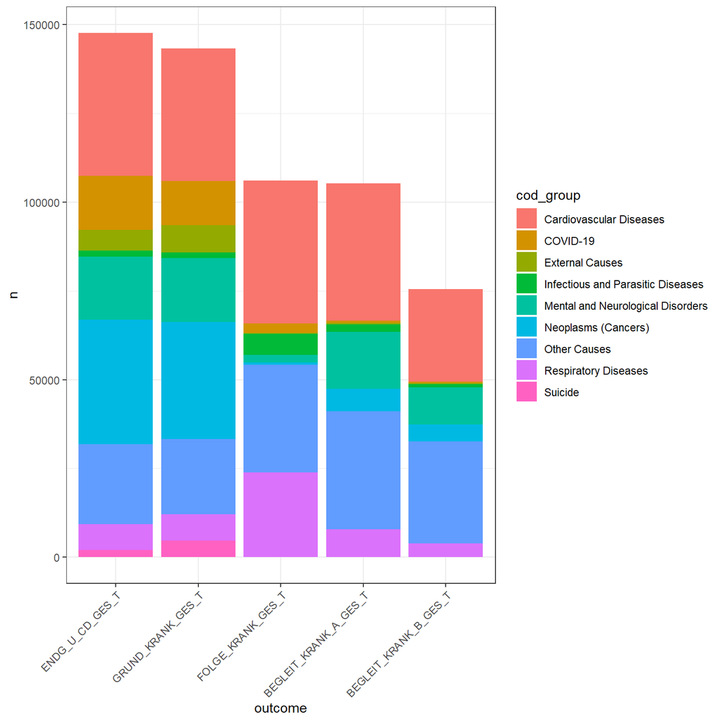

### 2.1.2 Correlation: principal and primary

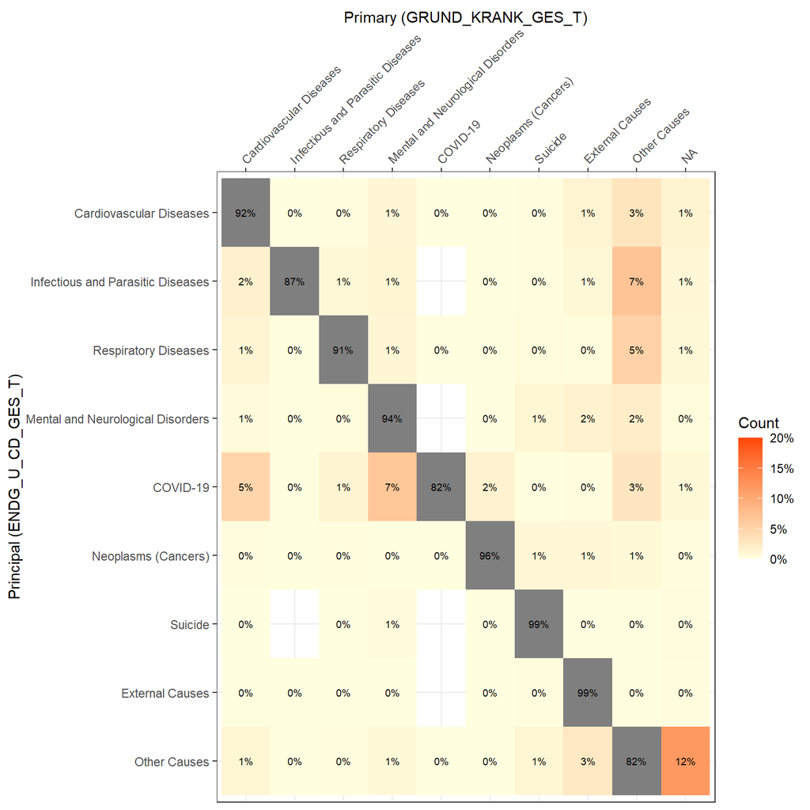

### 2.1.3 Correlation: principal and secondary

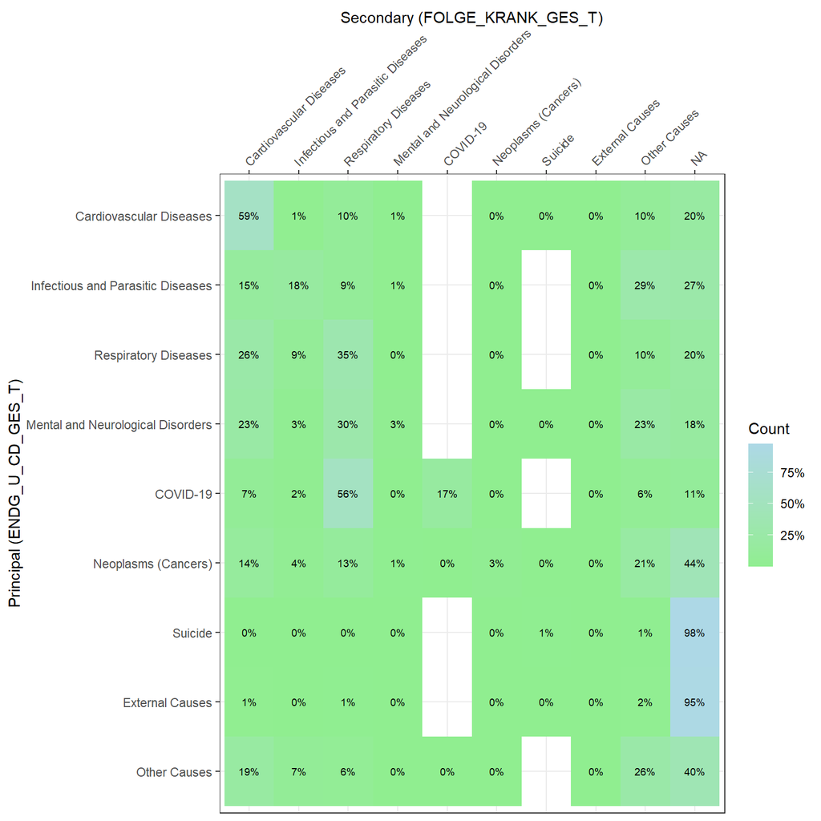

## 2.2 Reported deaths

- individual, with information about the calendar year, calendar week, exact age, canton and sex
- ICD-10 code of the cause of deaths, as well as secondary and other causes

```
##  [1] "LAUF_KS_N"             "SJAHR_N"               "GEBURT_JJJJ_GES_N"
##  [4] "EREIGNIS_MM_GES_N"     "EREIGNIS_JJJJ_GES_N"   "EREIGNIS_KW_GES_N"
##  [7] "EREIGNIS_KJ_GES_N"     "P_ALTER_ERFUELLT_N"    "GESCHLECHT_CD_GES_T"
## [10] "GRUND_KRANK_GES_T"     "FOLGE_KRANK_GES_T"     "BEGLEIT_KRANK_A_GES_T"
## [13] "BEGLEIT_KRANK_B_GES_T" "ENDG_U_CD_GES_T"       "WORT_AKT_ST_N"
## [16] "WORT_SITZ_CD_N"        "WOHNKANTON_AKT_N"      "WORT_AKT_GEM_N"
## [19] "ST_AKT_N"              "ST_KANTON_GES_N"
```

### 2.2.1 ICD-10 code

| icd10Chapter | icd10Title |
| --- | --- |
| I | Certain infectious and parasitic diseases |
| II | Neoplasms |
| III | Diseases of the blood and blood-forming organs and certain disorders involving the immune mechanism |
| IV | Endocrine, nutritional and metabolic diseases |
| V | Mental and behavioural disorders |
| VI | Diseases of the nervous system |
| VII | Diseases of the eye and adnexa |
| VIII | Diseases of the ear and mastoid process |
| IX | Diseases of the circulatory system |
| X | Diseases of the respiratory system |
| XI | Diseases of the digestive system |
| XII | Diseases of the skin and subcutaneous tissue |
| XIII | Diseases of the musculoskeletal system and connective tissue |
| XIV | Diseases of the genitourinary system |
| XV | Pregnancy, childbirth and the puerperium |
| XVI | Certain conditions originating in the perinatal period |
| XVII | Congenital malformations, deformations and chromosomal abnormalities |
| XVIII | Symptoms, signs and abnormal clinical and laboratory findings, not elsewhere classified |
| XIX | Injury, poisoning and certain other consequences of external causes |
| XX | External causes of morbidity and mortality |
| XXI | Factors influencing health status and contact with health services |
| XXII | Codes for special purposes |

### 2.2.2 By cause and age, over calendar year

### 2.2.3 Comparison with mortality reported by FSO

### 2.2.4 Comparison with data from excess mortality

## 2.3 Population

To predict the mortality risk by age group, we need to adjust for the population size. We retrieve the population for each age group on the 1st of January of each year from FSO website and interpolate it to obtain the weekly population.

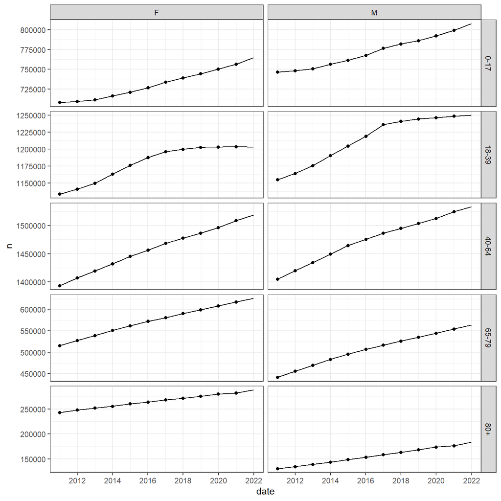

# 3 Analysis

We model the changes of mortality risk over time using two Gaussian Processes (GPs). We use an offset for the total population $N$ in the given age group:

$$\log\mu_{ijk} = \alpha +
\beta_{F}\mathbb{1}_{i=F} + f(t) + g(t) + \log(N)$$
where $\alpha$ is the intercept,$\beta_F$ is the effect of being a female on the mortality and $N$ is the population. The GP $f$ models the long-term trend in mortality over time while the GP $g$ represents the change in mortality over the weeks of the year. We assume an exponential quadratic Kernel for $f$ and a periodic Kernel for $g$.

## 3.2 Excess mortality

The model provides estimates of the weekly expected mortality by cause and age class in 2020. We obtain the excess mortality by subtracting the expected mortality to the reported number of deaths.

# 4 Results

## 4.1 Model fit

### 4.1.1 By cause

#### 4.1.1.1 0-17

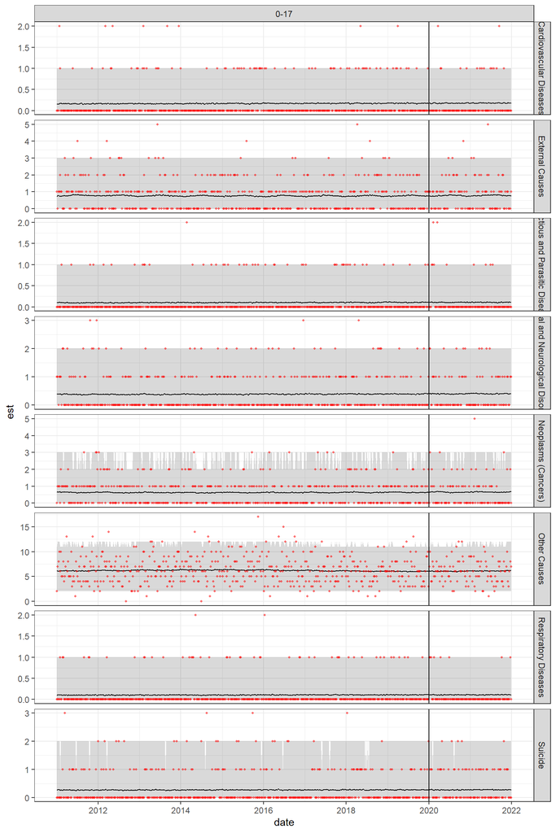

#### 4.1.1.2 18-39

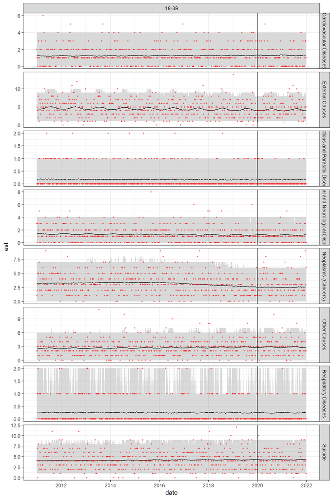

#### 4.1.1.3 40-64

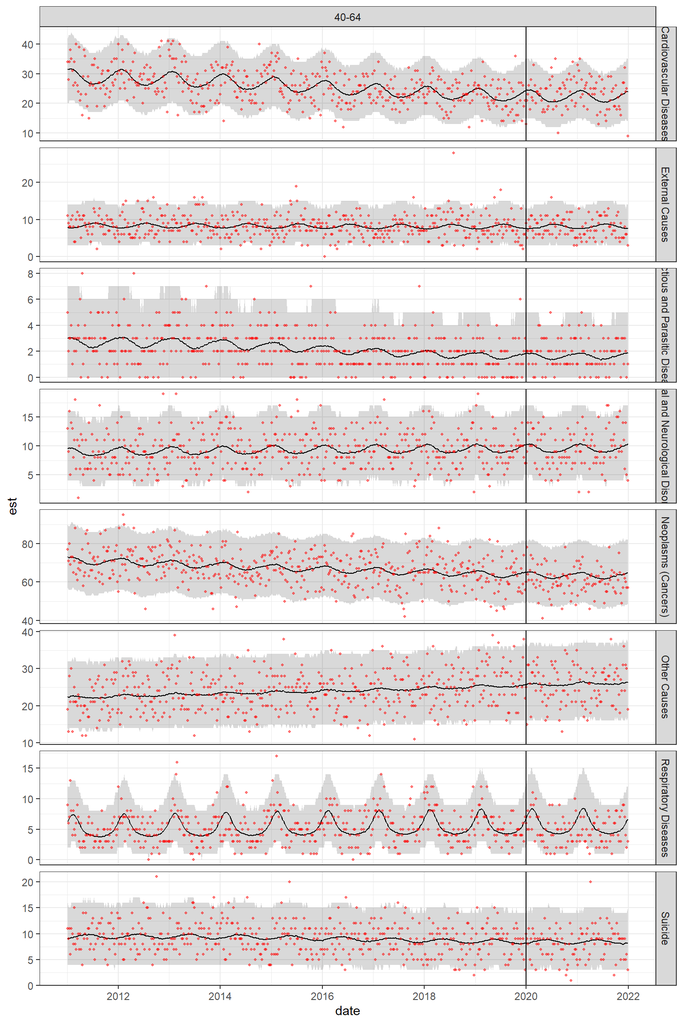

#### 4.1.1.4 65-79

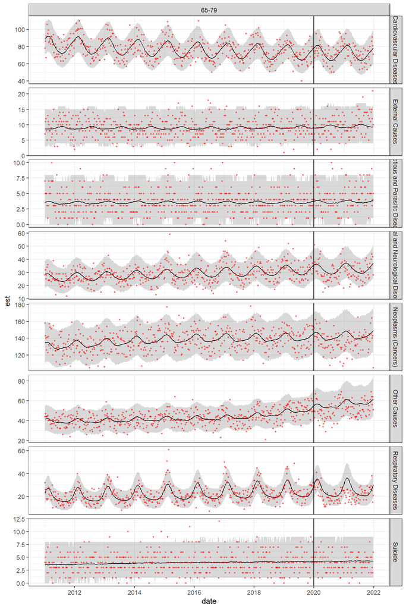

#### 4.1.1.5 80+

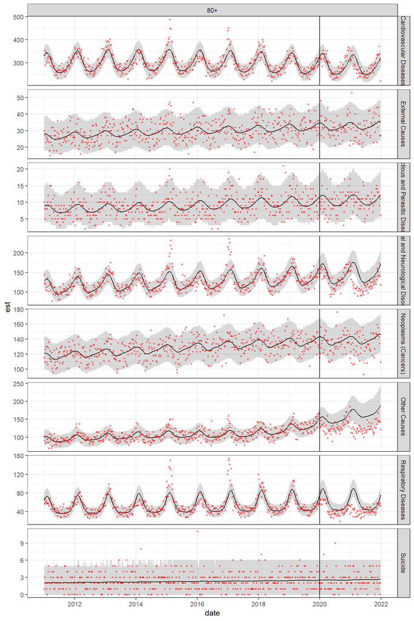

### 4.1.2 Aggregated over causes

Red: overall deaths. Blue: deaths without COVID-19.

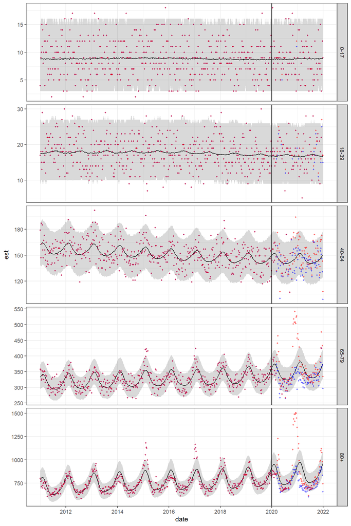

## 4.2 Expected mortality

### 4.2.1 by year, by cause

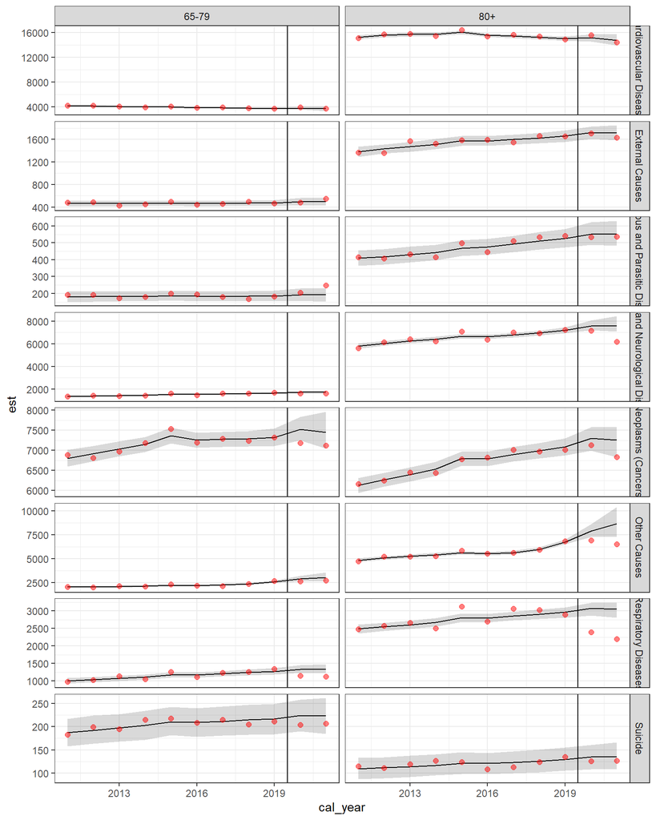

### 4.2.2 by year, aggregated

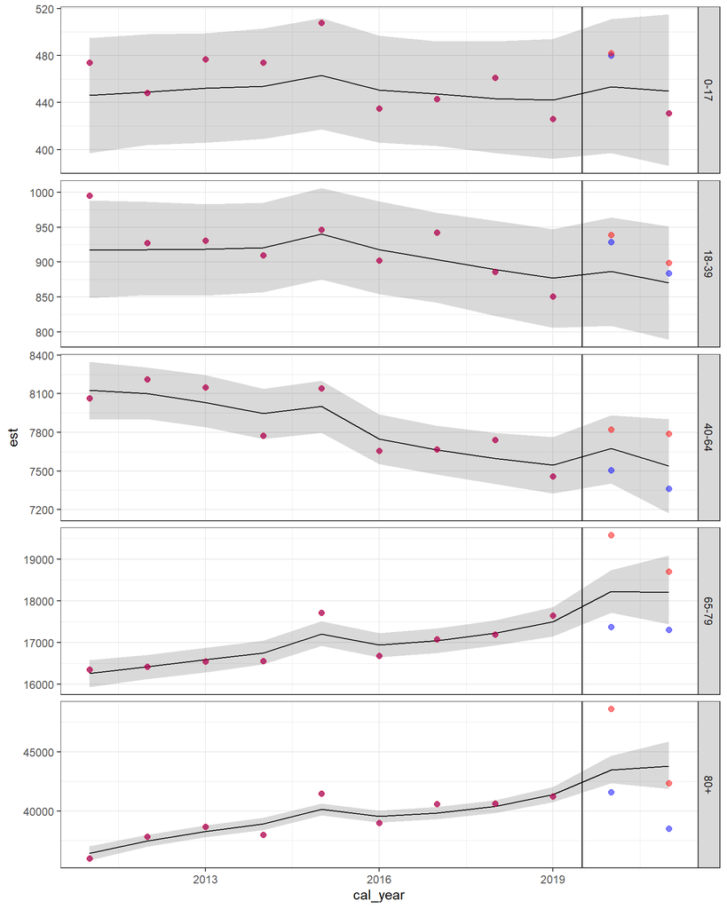

### 4.2.3 by phase

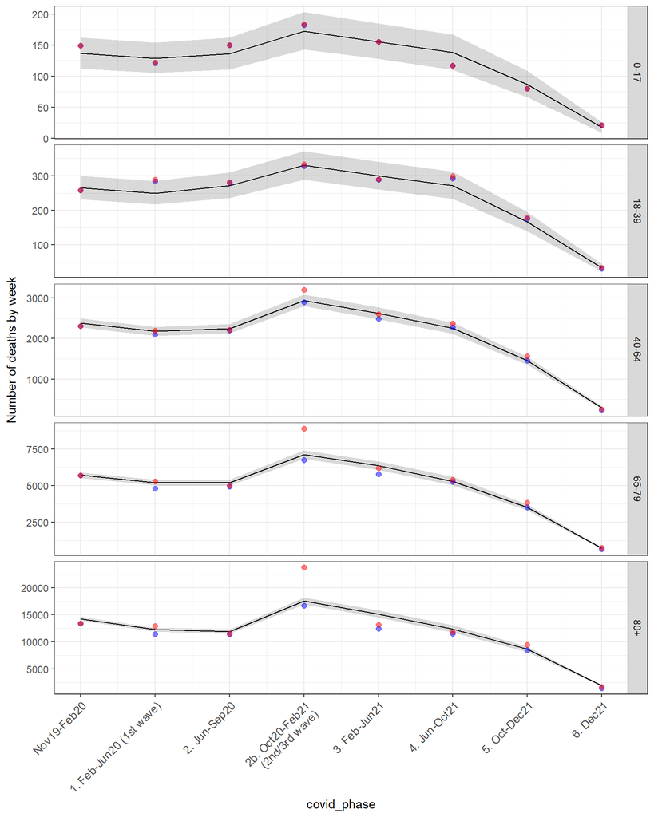

## 4.3 Excess mortality

### 4.3.1 Aggregated over causes, by age and year

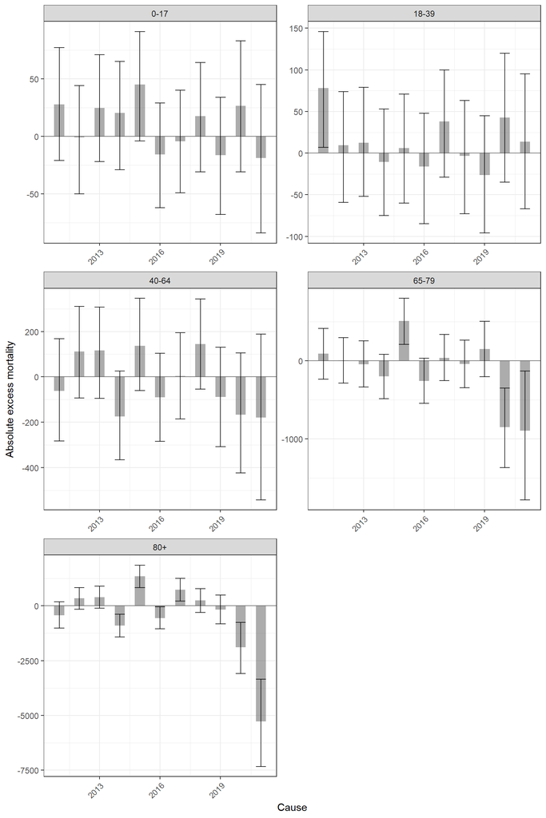

### 4.3.2 By causes and year, 80+

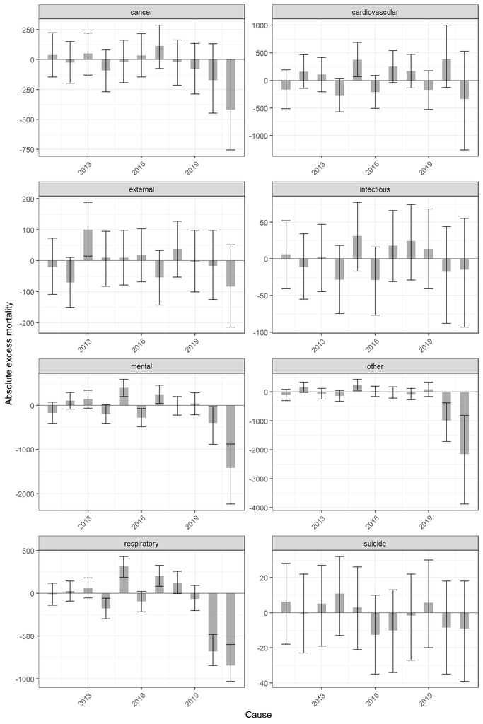

### 4.3.3 By causes and age, 2020-21

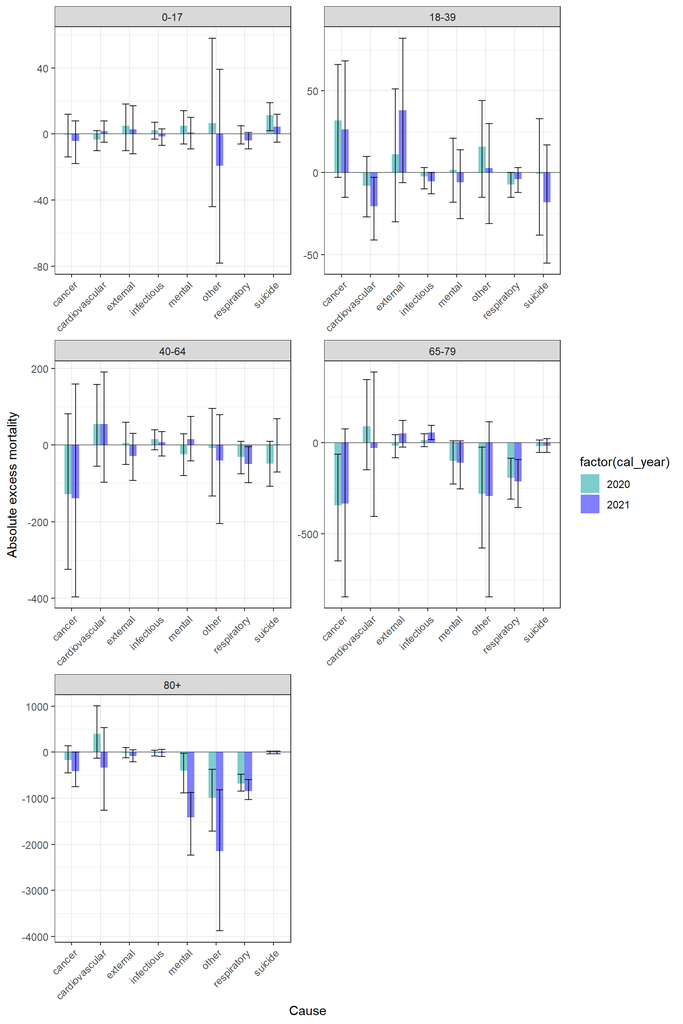

### 4.3.4 by phase

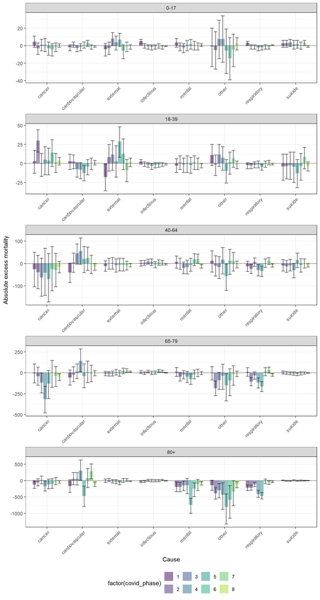

## 4.4 Gaussian processes

### 4.4.1 Long-term trend

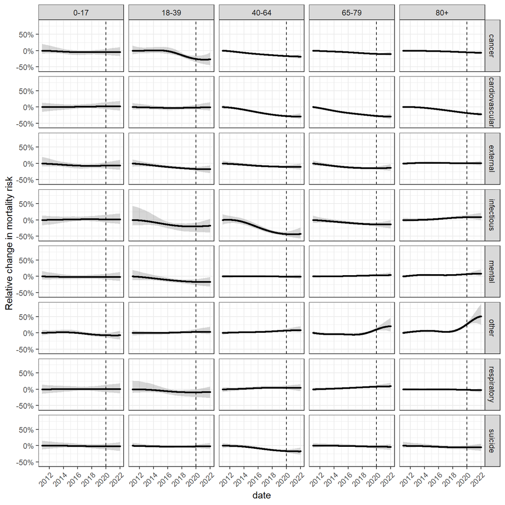

### 4.4.2 Periodic trend

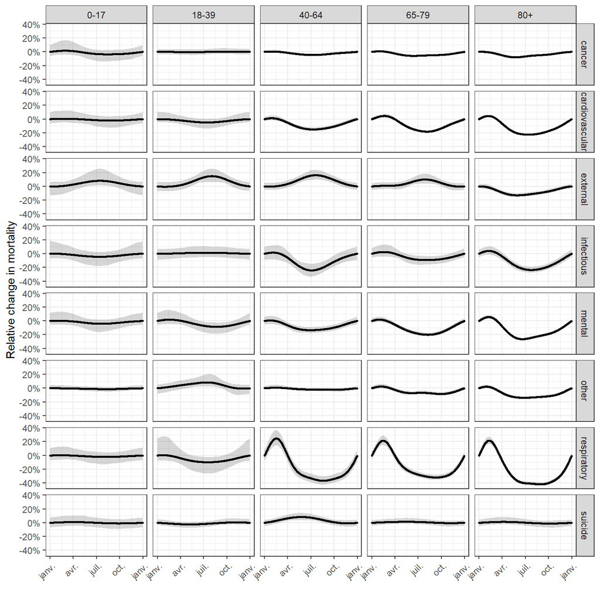

## 4.5 Correlation

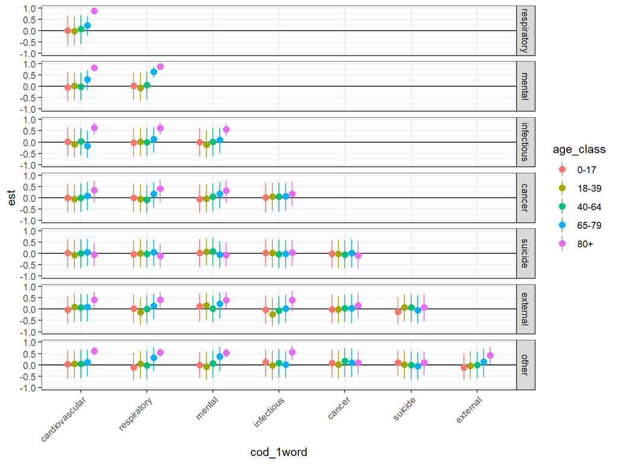

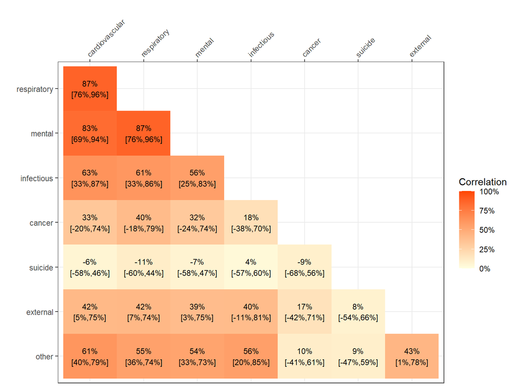

## 4.6 Regression

### 4.6.1 Sex differences

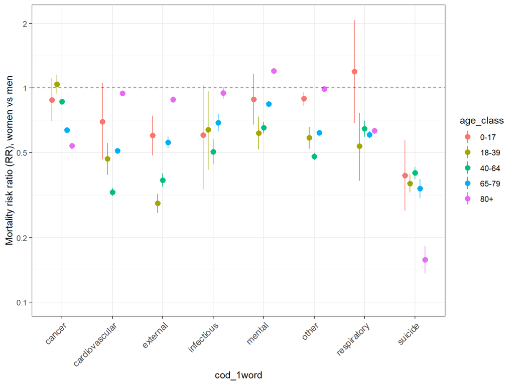

### 4.6.2 Regional differences

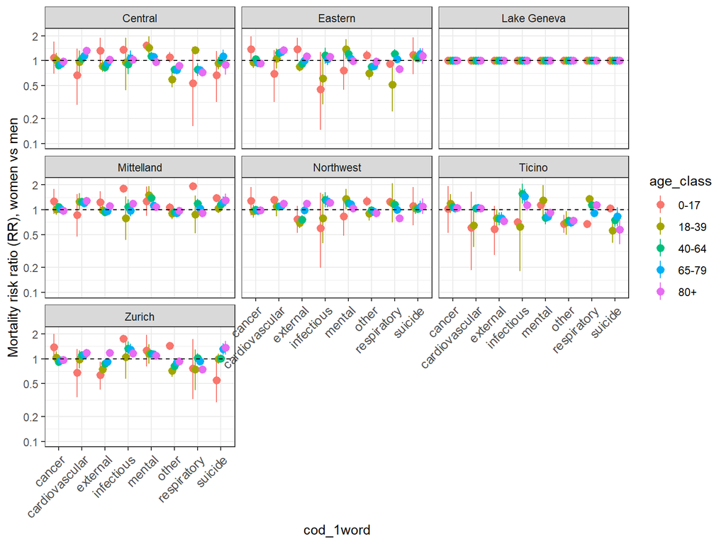

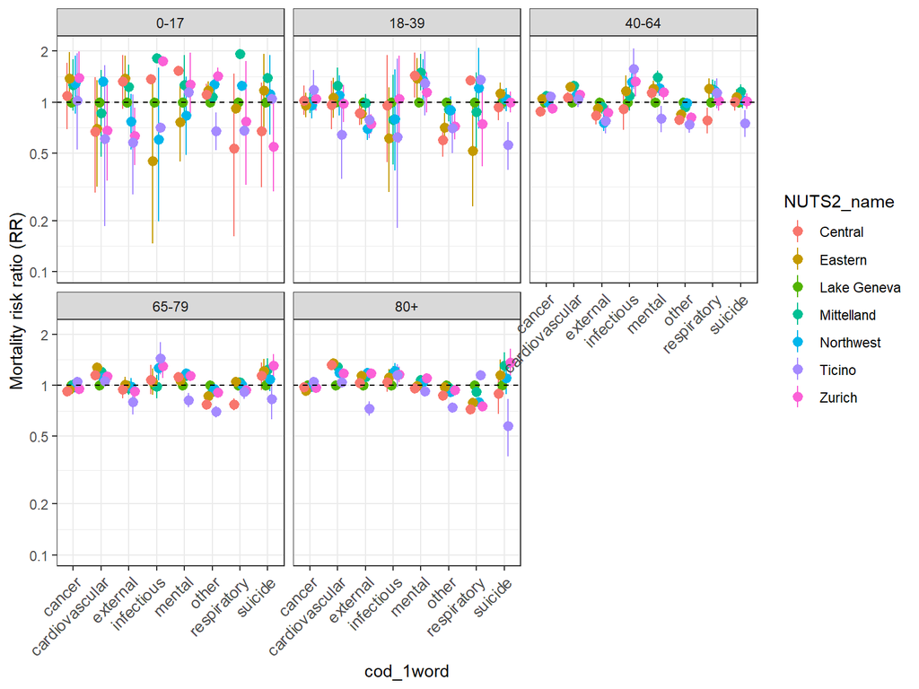

## 4.7 Correlation with COVID-19

### 4.7.1 Plot

For 80+.

```
## 'cod_group'. You can override using the `.groups` argument.
```

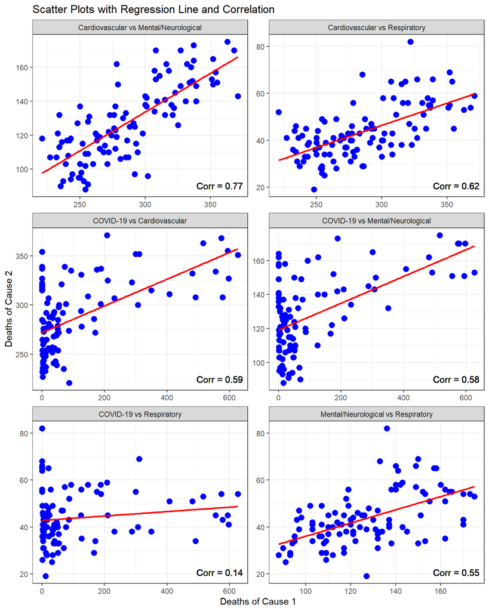

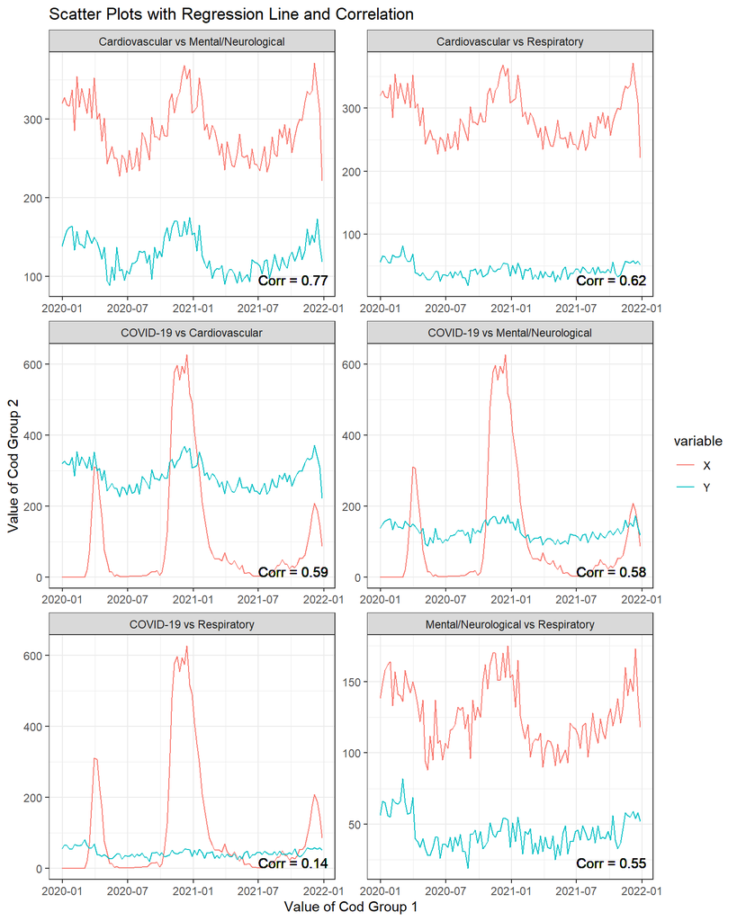

### 4.7.2 with lags

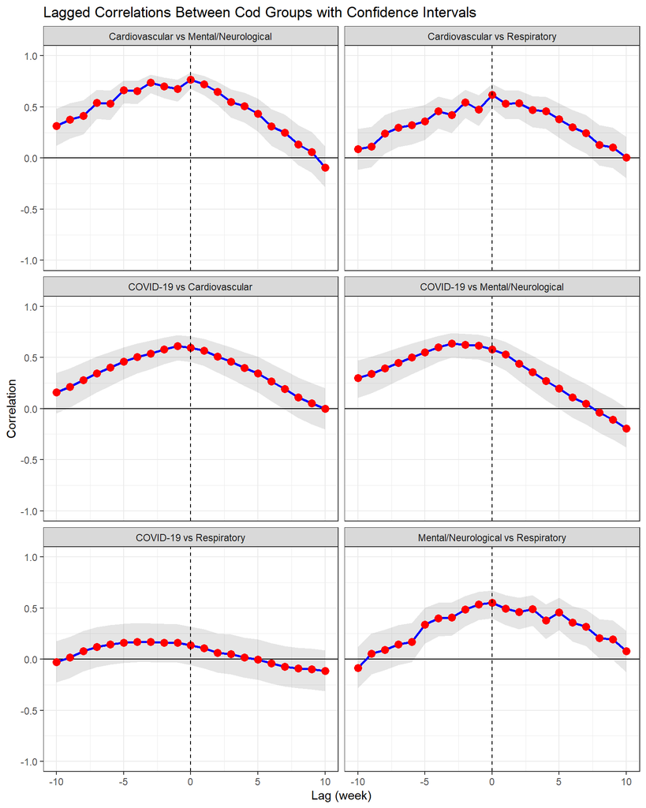